# Topic models - analiza wątku (tematu)

Bogna Zacny

zima 2019/2020

## Przygotowanie środowiska

Przydatne pakiety

```
install.packages(c("topicmodels", "tm", "ggplot2", "dplyr", "tidyr"))

library("topicmodels")
library("tm")
library("ggplot2")
library("dplyr")
library("tidyr")
```

## Topic modeling z biblioteką `topicmodels`

> Przykład

```r
tekst_topic <- c("I had a peanut butter sandwich for breakfast.",
                 "I like to eat almonds, peanuts and walnuts.",
                 "My neighbor got a little dog yesterday.",
                 "Cats and dogs are mortal enemies.",
                 "You mustn’t feed peanuts to your dog.")
```

Odkrywanie tematu dokumentów przy wykorzystaniu biblioteki `topicmodels` wymaga przygotowania macierzy dokument term.

```r
zrodlo_topic <- VectorSource(tekst_topic)
korpus_topic <- VCorpus(zrodlo_topic)

dtm_topic <-  DocumentTermMatrix(korpus_topic,
                                 control = list(stemming = TRUE,
                                                stopwords = TRUE,
                                                removeNumbers = TRUE,
                                                removePunctuation = TRUE))
as.matrix(dtm_topic)
```

```
##     Terms
## Docs almonds breakfast butter cat dog eat enemies feed got like littl
##    1       0         1      1   0   0   0       0    0   0    0     0
##    2       1         0      0   0   0   1       0    0   0    1     0
##    3       0         0      0   0   1   0       0    0   1    0     1
##    4       0         0      0   1   1   0       1    0   0    0     0
##    5       0         0      0   0   1   0       0    1   0    0     0
##     Terms
## Docs mortal mustn’t neighbor peanut sandwich walnuts yesterday
##    1      0       0        0      1        1       0         0
##    2      0       0        0      1        0       1         0
##    3      0       0        1      0        0       0         1
##    4      1       0        0      0        0       0         0
##    5      0       1        0      1        0       0         0
```

Liczebność termów w dokumentach

```r
colSums(as.matrix(dtm_topic))
```

```
##   almonds breakfast    butter       cat       dog       eat   enemies
##         1         1         1         1         3         1         1
##      feed       got      like     littl    mortal   mustn’t  neighbor
##         1         1         1         1         1         1         1
##    peanut  sandwich   walnuts yesterday
##         3         1         1         1
```

*Topic models* jest rozszerzeniem klasycznych metod w przetwarzana języka naturalnego, takich jak *unigram model* i *Latent Semantic Analysis*. w poszukiwaniu tematu (wątku) dokumentu wykorzystuje się jedną z metod redukcji wymiaru przestrzeni cech: **latent Dirichlet allocation** (**LDA**) - to statystyczny model, który opisuje (hipotetyczny) proces losowy generujący kolejne słowa każdego dokumentu zgodnie z rozkładem tematów w dokumencie.

W bibliotece `topicmodels` dostępna jest funkcja **`LDA()`** pozwalająca na zbudowanie modelu tematów.

```r
lda_topic <- LDA(dtm_topic, 2, control = list(seed = 1652))
# str(lda_topic)
```

Korzystając z dedykowanych funkcji biblioteki `topicmodels` możemy wybrać z obiektu klasy **`LDA`** intersujące nas informacje:

- numer dokumentu z numerem prawdopodobnego wątku

```r
(tematy <- topics(lda_topic))
```

```
## 1 2 3 4 5
## 1 1 2 2 1
```

- najistotniejszy term dla wątku

```r
(tematy_term <- terms(lda_topic))
```

```
##  Topic 1  Topic 2
## "peanut"    "dog"
```

- opis każdego dokumentu: nr wątku + najistotniejszy term

```r
tematy_term[tematy]
```

```
##  Topic 1  Topic 1  Topic 2  Topic 2  Topic 1
## "peanut" "peanut"    "dog"    "dog" "peanut"
```

Chcąc zachować wszystkie istotne informacje w jednej tabeli można stworzyć tabelę danych:

```r
(tematy1_df <- tibble(dokument = 1:5, Tekst = tekst_topic, Tematy=tematy_term[tematy]))
```

```
## # A tibble: 5 x 3
##   dokument Tekst                                         Tematy
##      <int> <chr>                                         <chr>
## 1        1 I had a peanut butter sandwich for breakfast. peanut
## 2        2 I like to eat almonds, peanuts and walnuts.   peanut
## 3        3 My neighbor got a little dog yesterday.       dog
## 4        4 Cats and dogs are mortal enemies.             dog
## 5        5 You mustn’t feed peanuts to your dog.         peanut
```

Gdy chcemy dokładniej zinterpretować wątki - należy przyjrzeć się większej liczbie termów każdego wątku.

```r
(tematy_termy4 <- terms(lda_topic, 4))
```

```
##      Topic 1   Topic 2
## [1,] "peanut"  "dog"
## [2,] "butter"  "peanut"
## [3,] "mustn’t" "littl"
## [4,] "dog"     "like"
```

```r
tematy_termy4[2,][tematy]
```

```
##  Topic 1  Topic 1  Topic 2  Topic 2  Topic 1
## "butter" "butter" "peanut" "peanut" "butter"
```

Zapisanie wszystkich informacji w jednej tabeli

```r
tematy_termy4_string <- apply(tematy_termy4, 2, paste, collapse = "/ ")
(tematy4_df <- data.frame(dokument = 1:5, Tekst = tekst_topic, Wątek = tematy, Termy = tematy_termy4_string[tematy]))
```

```
##   dokument                                         Tekst Wątek
## 1        1 I had a peanut butter sandwich for breakfast.     1
## 2        2   I like to eat almonds, peanuts and walnuts.     1
## 3        3       My neighbor got a little dog yesterday.     2
## 4        4             Cats and dogs are mortal enemies.     2
## 5        5         You mustn’t feed peanuts to your dog.     1
##                          Termy
## 1 peanut/ butter/ mustn’t/ dog
## 2 peanut/ butter/ mustn’t/ dog
## 3     dog/ peanut/ littl/ like
## 4     dog/ peanut/ littl/ like
## 5 peanut/ butter/ mustn’t/ dog
```

“Ważność” termu dla danego tematu (wątku) zachowana jest w parametrze *beta*

```r
lda_topic@beta # exp() lub abs()
```

```
##           [,1]      [,2]      [,3]      [,4]      [,5]      [,6]      [,7]
## [1,] -3.189024 -2.835105 -2.527246 -3.787726 -2.712405 -2.859857 -3.274706
## [2,] -3.001976 -3.435089 -4.501039 -2.685053 -1.578841 -3.391588 -2.936214
##           [,8]      [,9]     [,10]     [,11]     [,12]     [,13]     [,14]
## [1,] -2.789180 -2.955704 -3.973158 -4.050110 -3.565688 -2.644985 -2.975777
## [2,] -3.524426 -3.247278 -2.630488 -2.611368 -2.771020 -3.914405 -3.221075
##          [,15]     [,16]     [,17]     [,18]
## [1,] -1.679208 -2.745299 -2.912939 -3.475007
## [2,] -2.449887 -3.622471 -3.307421 -2.814757
```

```r
beta_df <- data_frame(term = lda_topic@terms, wątek1 = exp(lda_topic@beta[1, ]), wątek2 = exp(lda_topic@beta[2, ]))
```

Wizualizacja ważności termów w wątkach

```r
beta_tidy <- gather(beta_df, wątek, beta, -term)

beta_top <- beta_tidy %>%
  group_by(wątek) %>%
  top_n(5, beta) %>%
  ungroup() %>%
  arrange(wątek, -beta)
```

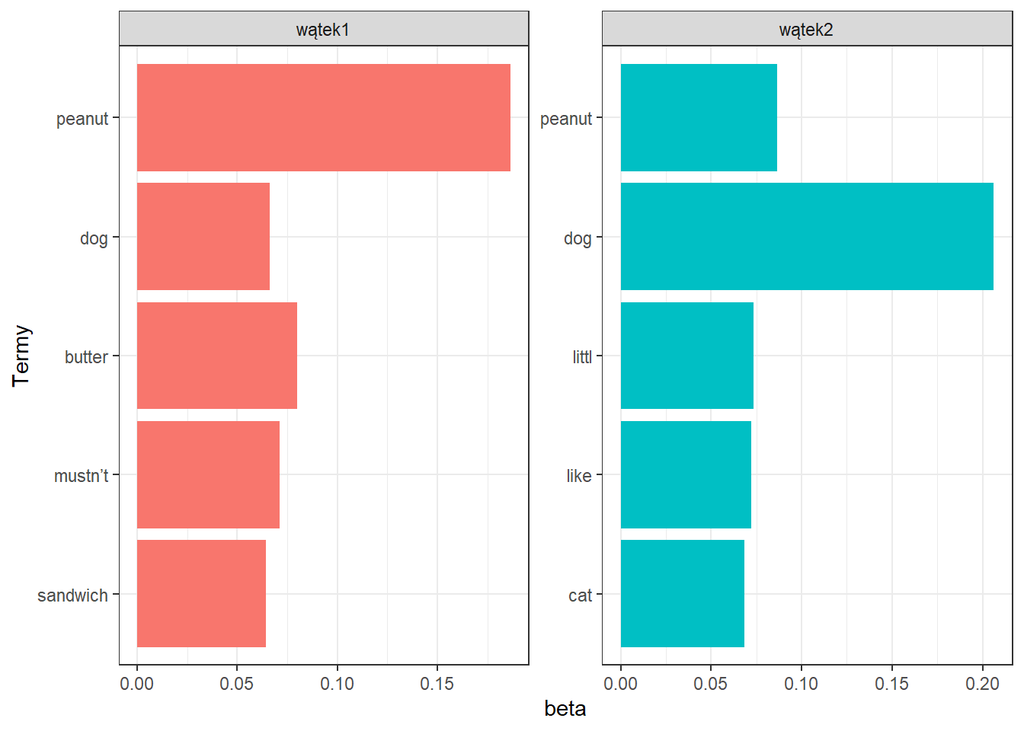

```r
ggplot(beta_top, aes(reorder(term, beta), beta, fill = wątek)) +
  geom_col(show.legend = FALSE) +
  facet_wrap(~ wątek, scales = "free") +
  labs(x = "Termy") +
  coord_flip() +
  theme_bw()
```

Wykorzystując wartości `beta` można obliczyć dla każdego termu szansę przynależności do jednego z tematów. Obliczając stosunek $\beta_{1}$ do $\beta_{2}$ wyznaczymy szansę przynależności do tematu **1** - im wyższa wartość tym większe szanse że term charakteryzuje temat **1**. Dodatkowo możemy obliczyć logarytm tego stosunku co pozwoli na przeskalowanie wartości w stosunku do zera, wówczas wartości dodatnie będą wskazywały na termy przynależne do wątku **1**, a ujemne na termy przynależne do wątku **2**. Zero oznacza, że term w równym stopniu przynależy do każdgo wątku.

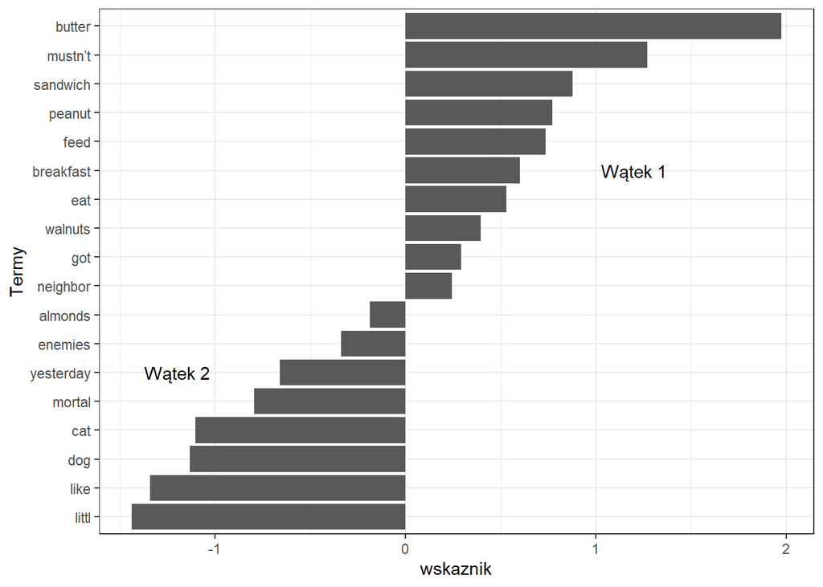

```r
beta_df %>%
  mutate(wskaznik = log(wątek1/wątek2)) %>%
  ggplot(aes(reorder(term, wskaznik), wskaznik)) +
  geom_col(show.legend = FALSE) +
  coord_flip() +
  annotate("text", x = c(6, 13), y = c(-1.2, 1.2), label = c("Wątek 2", "Wątek 1")) +
  labs(x = "Termy") +
  theme_bw()
```

“Ważność” wątku w dokumencie zachowana jest w parametrze *gamma*. Wartości *gamma* to oszacowana proporacja słów z danego dokumentu wygenerowana dla danego wątku. Czyli dla dokumentu 1 - 51% słów w dokumencie jest generowana z wątku 1 a 49% z wątku 2.

```r
lda_topic@gamma
```

```
##           [,1]      [,2]
## [1,] 0.5104936 0.4895064
## [2,] 0.5008235 0.4991765
## [3,] 0.4931990 0.5068010
## [4,] 0.4910125 0.5089875
## [5,] 0.5044155 0.4955845
```

```r
gamma_df <- data_frame(dokument = lda_topic@documents, wątek1 = lda_topic@gamma[, 1], wątek2 = lda_topic@gamma[, 2])
```

Wizualizacja rozkładu wątków w dokumentach

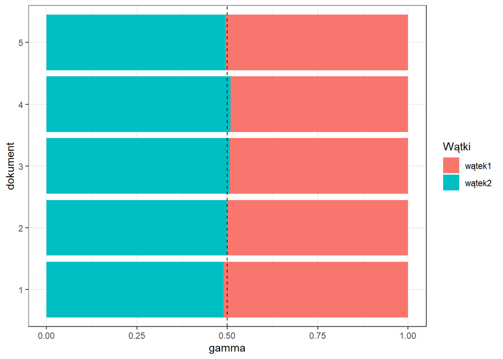

```r
gamma_tidy <- gather(gamma_df, wątek, gamma, -dokument)

gamma_tidy %>%
  ggplot(aes(dokument, gamma, fill = wątek)) +
  geom_col(position = "stack") +
  geom_hline(yintercept = 0.5, linetype = 2) +
  coord_flip() +
  labs(fill = "Wątki") +
  theme_bw()
```

Wyznaczenie wskaźnika `log-ratio`

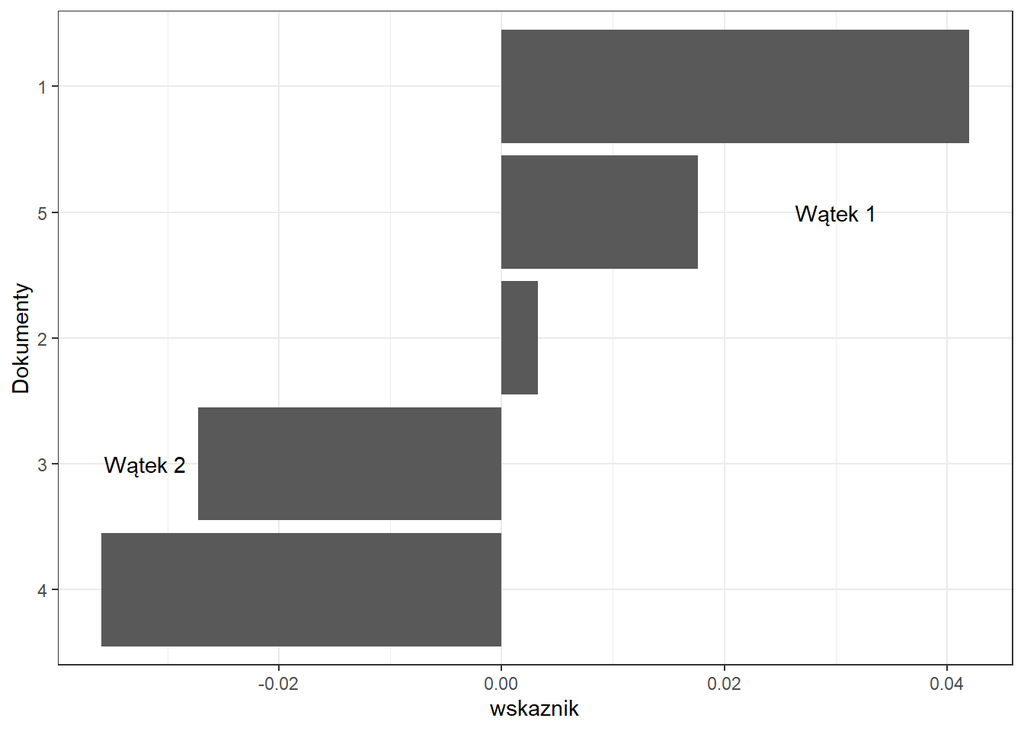

```r
gamma_df %>%
  mutate(wskaznik = log(wątek1/wątek2)) %>%
  ggplot(aes(reorder(dokument, wskaznik), wskaznik)) +
  geom_col(show.legend = FALSE) +
  coord_flip() +
  annotate("text", x = c(2, 4), y = c(-0.032, 0.03), label = c("Wątek 2", "Wątek 1")) +
  labs(x = "Dokumenty") +
  theme_bw()
```

### Zadanie

Przeprowadź analizę wątków dla zbioru recenzji. Korpus należy oczyścić w następujących krokach.

```
rec_korpus <- tm_map(rec_korpus, content_transformer(tolower))
rec_korpus <- tm_map(rec_korpus, removeNumbers)
rec_korpus <- tm_map(rec_korpus, removeWords, c(stopwords("en"), "one", "two", "three", "make", "get", "movie", "movies", "film", "films"))
rec_korpus <- tm_map(rec_korpus, stemDocument)
rec_korpus <- tm_map(rec_korpus, removePunctuation)
rec_korpus <- tm_map(rec_korpus, stripWhitespace)
```